# Project 2 Description

# 5 Descriptive analysis

## 5.1 Histogram

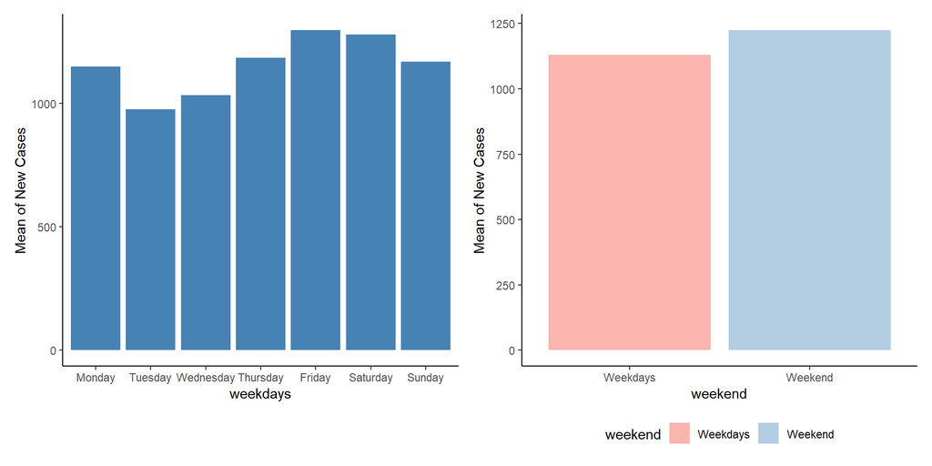

```r
library(patchwork)
covid$weekdays <- factor(weekdays(covid$Date_reported),
    levels=c('Monday','Tuesday','Wednesday','Thursday','Friday','Saturday','Sunday'))
covid$weekend <- ifelse(weekdays(covid$Date_reported)%in%c('Saturday','Sunday'),'Weekend','Weekdays')#Change the day of the week into a binary variable, weekend or weekday
#p1 is the histogram from Monday to Sunday, p2 is the histogram for weekends and weekdays
p1<- covid%>%
  group_by(weekdays)%>%
  summarise(New_cases = mean(New_cases))%>%
  ggplot(aes(weekdays,New_cases))+
  geom_col(fill='steelblue')+
  theme_classic()+
  ylab('Mean of New Cases')

p2<-covid%>%
  group_by(weekend)%>%
  summarise(New_cases = mean(New_cases))%>%
  ggplot(aes(weekend,New_cases,fill=weekend))+
  geom_col()+
  scale_fill_brewer(palette = 'Pastel1')+
  theme_classic()+
  theme(legend.position = 'bottom')+
  ylab('Mean of New Cases')
p1+p2
```

Although the histogram finds the difference in the number of new COVID-19 newcomers on weekends and weekdays, we do not know whether this difference is significant. Therefore, we use linear regression to explore whether the difference between the number of new COVID-19 people on weekends and weekdays is significant, and what the specific difference is.

The dependent variable of the linear model is the number of new people, and the independent variable is whether it is a weekend (binary variable). At the same time, linear regression requires the dependent variable to obey a normal distribution. In fact, the number of newly-increased people obeys the Poisson distribution. From the histogram of newly-increased people, it can be seen that the number of newly-increased people is obviously to the right and does not follow the normal distribution. It can be seen from the transformed histogram that the number of newly-increased people after logarithmization is more symmetrical and can be used as a dependent variable for linear regression.

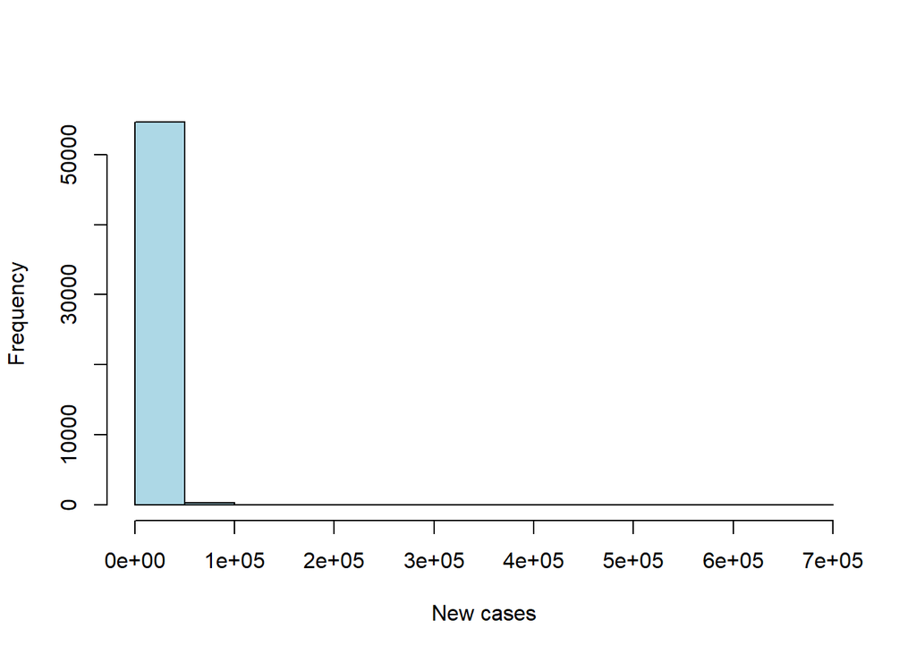

```r
a <- subset(covid,New_cases>0)#Extract new people>0, because log must require x to be greater than 0
hist(a$New_cases,xlab='New cases',main='',col='lightblue')#New cases histogram
```

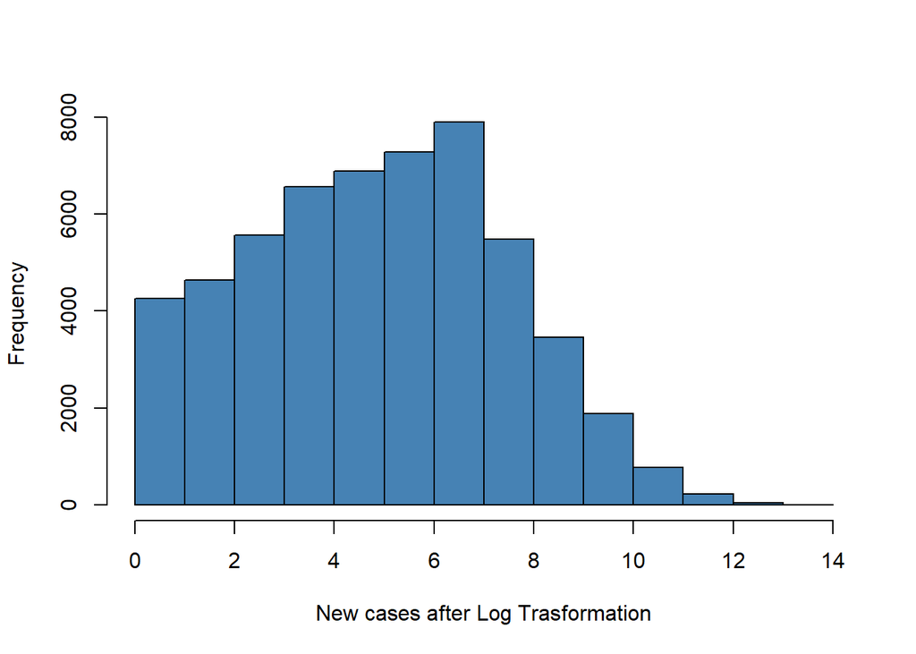

```r
hist(log(a$New_cases),xlab='New cases after Log Trasformation',main='',col='steelblue')#Histogram after logarithmization of new cases
```

## 5.2 Best fit model

```r
fit <- lm(log(New_cases)~weekend,data=a)
summary(fit)
```

```
##
## Call:
## lm(formula = log(New_cases) ~ weekend, data = a)
##
## Residuals:
##     Min      1Q  Median      3Q     Max
## -4.9265 -1.9365  0.0858  1.8849  8.4844
##
## Coefficients:
##                Estimate Std. Error t value Pr(>|t|)
## (Intercept)     4.82683    0.01306 369.651  < 2e-16 ***
## weekendWeekend  0.09963    0.02462   4.046 5.21e-05 ***
## ---
## Signif. codes:  0 '***' 0.001 '**' 0.01 '*' 0.05 '.' 0.1 ' ' 1
##
## Residual standard error: 2.595 on 54962 degrees of freedom
## Multiple R-squared:  0.0002978,  Adjusted R-squared:  0.0002796
## F-statistic: 16.37 on 1 and 54962 DF,  p-value: 5.214e-05
```

# 6 Sensitivity analysis.

## 6.1 Residual vs Fitted values

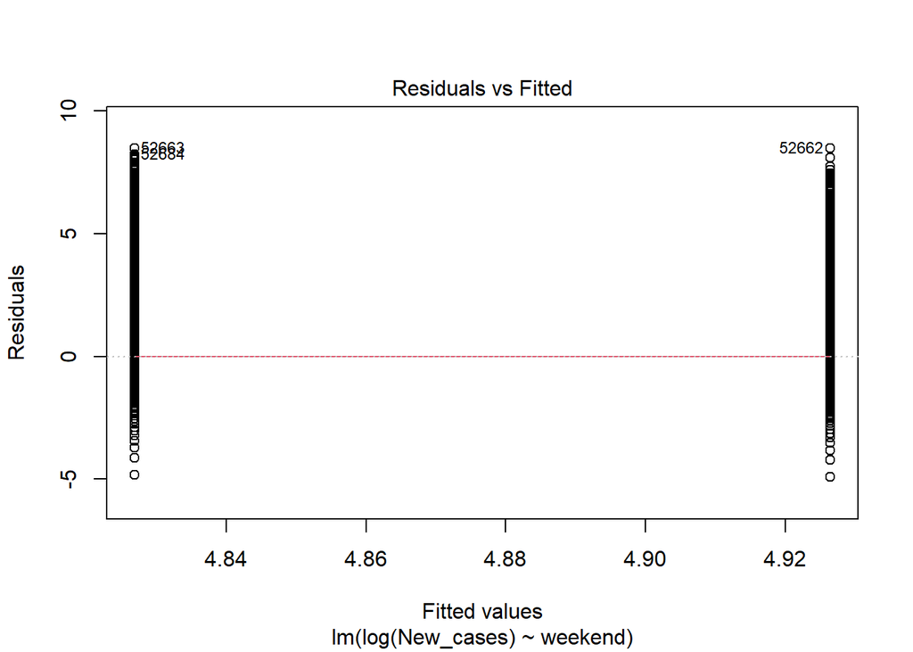

```r
plot(fit,1)
```

The vertical plots indicated there is two group of variables and there is no outline of any points, which mean there is no missing values of the function. And the horizontal red line is perfectly fit on the solid line, that concluded that the variance of the error terms are equal,and the observations of residuals are equal to zero .

## 6.2 Q-Q normal plot

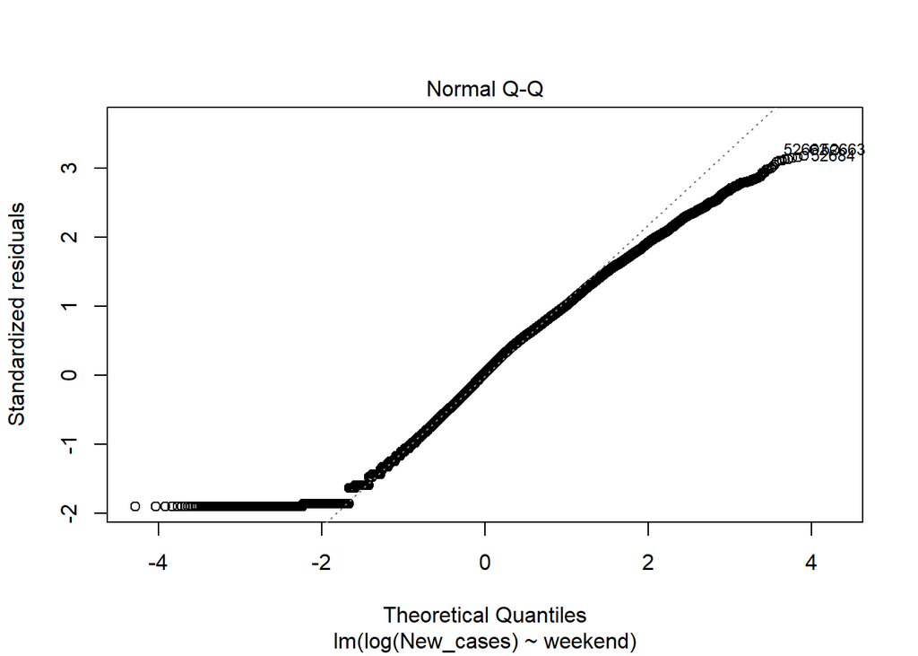

```r
plot(fit,2)
```

## 6.3 Boxcox Transfromation

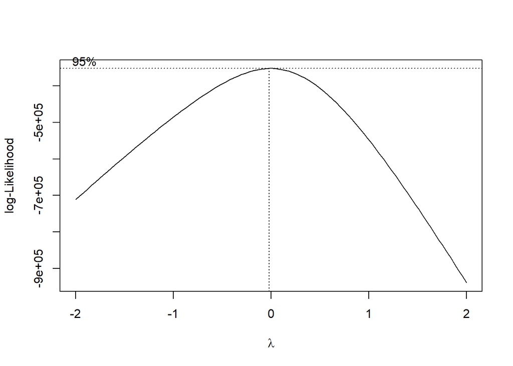

```r
fit2=lm(New_cases~weekend,data=a)
boxcox(fit2)
```

The points are vary from the straight line when the quantiles at around -1.5 and 1.5 in the normal Q-Q.Therefore the assumption is not a normality distribution. Then we use a boxcox function try to do a transformation for the Q-Q plot, but we found that the lambda is equal to zero, so that verified using log for the model is the best fitted for the graph.

## 6.4 scaled location plot

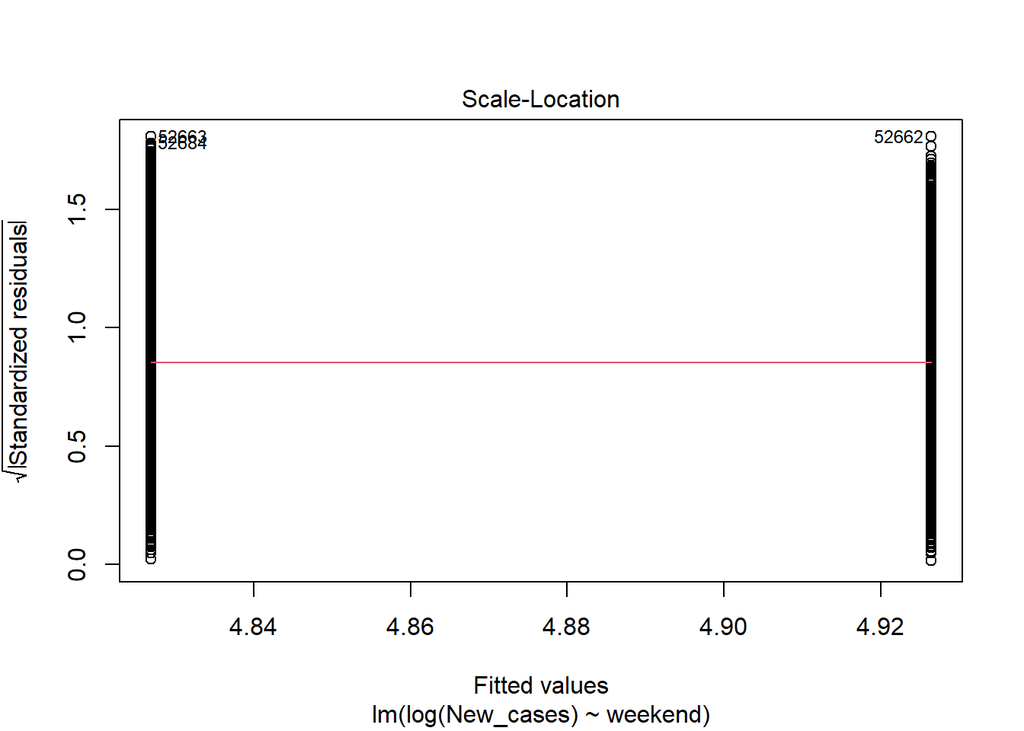

```r
plot(fit,3)
```

## 6.5 Breusch-Pagan test

```r
bptest(fit)
```

```
##
##  studentized Breusch-Pagan test
##
## data:  fit
## BP = 2.6574, df = 1, p-value = 0.1031
```